# Final Project - Titanic Passengers

Iffah Mohamad Saufi

#### 1) Research Question:

##### Does survivors mostly came from the first class during the Titanic incident?

#### 2) Data Sources

##### Primary Source: The data comes from Wikipedia. It was collected after the titanic incident since the survivors were also included in the data.

##### Second Source: From R package called vcdExtra.

##### There are 1309 cases and each of them represents the passenger of the Titanic ship. For this project, I am planning to use passenger Id, name, survived, class, age, gender, fare and embarked variables.

```r
# clean up R environment
rm(list = ls())

# load packages
library(tidyverse)
library(mosaic)
library(mdsr)
library(DataComputing)
library(vcdExtra)
library(dplyr)
```

```r
# Read Primary Data into R
Passenger <- read.csv("full.csv")

# inspect data
head(Passenger)
```

|  | PassengerId | Survived | Pclass | Name | Sex | Age | SibSp | Parch | Ticket | Fare | Cabin | Embarked | WikiId | Name_wiki | Age_wiki | Hometown | Boarded | Destination | Lifeboat | Body | Class |
| --- | --- | --- | --- | --- | --- | --- | --- | --- | --- | --- | --- | --- | --- | --- | --- | --- | --- | --- | --- | --- | --- |
| 1 | 1 | 0 | 3 | Braund, Mr. Owen Harris | male | 22 | 1 | 0 | A/5 21171 | 7.2500 |  | S | 691 | Braund, Mr. Owen Harris | 22 | Bridgerule, Devon, England | Southampton | Qu'Appelle Valley, Saskatchewan, Canada |  |  | 3 |
| 2 | 2 | 1 | 1 | Cumings, Mrs. John Bradley (Florence Briggs Thayer) | female | 38 | 1 | 0 | PC 17599 | 71.2833 | C85 | C | 90 | Cumings, Mrs. Florence Briggs (née Thayer) | 35 | New York, New York, US | Cherbourg | New York, New York, US | 4 |  | 1 |
| 3 | 3 | 1 | 3 | Heikkinen, Miss. Laina | female | 26 | 0 | 0 | STON/O2. 3101282 | 7.9250 |  | S | 865 | Heikkinen, Miss Laina | 26 | Jyväskylä, Finland | Southampton | New York City | 14? |  | 3 |
| 4 | 4 | 1 | 1 | Futrelle, Mrs. Jacques Heath (Lily May Peel) | female | 35 | 1 | 0 | 113803 | 53.1000 | C123 | S | 127 | Futrelle, Mrs. Lily May (née Peel) | 35 | Scituate, Massachusetts, US | Southampton | Scituate, Massachusetts, US | D |  | 1 |
| 5 | 5 | 0 | 3 | Allen, Mr. William Henry | male | 35 | 0 | 0 | 373450 | 8.0500 |  | S | 627 | Allen, Mr. William Henry | 35 | Birmingham, West Midlands, England | Southampton | New York City |  |  | 3 |
| 6 | 6 | 0 | 3 | Moran, Mr. James | male | NA | 0 | 0 | 330877 | 8.4583 |  | Q | 785 | Doherty, Mr. William John (aka "James Moran") | 22 | Cork, Ireland | Queenstown | New York City |  |  | 3 |

```r
str(Passenger)
```

```
'data.frame':   1309 obs. of  21 variables:
 $ PassengerId: int  1 2 3 4 5 6 7 8 9 10 ...
 $ Survived   : num  0 1 1 1 0 0 0 0 1 1 ...
 $ Pclass     : int  3 1 3 1 3 3 1 3 3 2 ...
 $ Name       : Factor w/ 1307 levels "Abbing, Mr. Anthony",..: 156 287 531 430 23 826 775 922 613 855 ...
 $ Sex        : Factor w/ 2 levels "female","male": 2 1 1 1 2 2 2 2 1 1 ...
 $ Age        : num  22 38 26 35 35 NA 54 2 27 14 ...
 $ SibSp      : int  1 1 0 1 0 0 0 3 0 1 ...
 $ Parch      : int  0 0 0 0 0 0 0 1 2 0 ...
 $ Ticket     : Factor w/ 929 levels "110152","110413",..: 721 817 915 66 650 374 110 542 478 175 ...
 $ Fare       : num  7.25 71.28 7.92 53.1 8.05 ...
 $ Cabin      : Factor w/ 187 levels "","A10","A11",..: 1 108 1 72 1 1 165 1 1 1 ...
 $ Embarked   : Factor w/ 4 levels "","C","Q","S": 4 2 4 4 4 3 4 4 4 2 ...
 $ WikiId     : num  691 90 865 127 627 ...
 $ Name_wiki  : Factor w/ 1304 levels "","Abbing, Mr. Anthony",..: 184 320 546 451 25 372 787 933 629 868 ...
 $ Age_wiki   : num  22 35 26 35 35 22 54 2 26 14 ...
 $ Hometown   : Factor w/ 567 levels "","Abbeyleix, Laois, Ireland[note 1]",..: 72 360 262 440 56 123 144 61 465 563 ...
 $ Boarded    : Factor w/ 5 levels "","Belfast","Cherbourg",..: 5 3 5 5 5 4 5 5 5 3 ...
 $ Destination: Factor w/ 292 levels "","Aberdeen, South Dakota, US",..: 217 187 186 242 186 186 73 57 250 60 ...
 $ Lifeboat   : Factor w/ 25 levels "","?","1","10",..: 1 15 9 25 1 1 1 1 10 2 ...
 $ Body       : Factor w/ 131 levels "","[66][67]",..: 1 1 1 1 1 1 38 1 1 1 ...
 $ Class      : int  3 1 3 1 3 3 1 3 3 2 ...
```

```r
glimpse(Passenger)
```

```
Observations: 1,309
Variables: 21
$ PassengerId <int> 1, 2, 3, 4, 5, 6, 7, 8, 9, 10, 1…
$ Survived    <dbl> 0, 1, 1, 1, 0, 0, 0, 0, 1, 1, 1,…
$ Pclass      <int> 3, 1, 3, 1, 3, 3, 1, 3, 3, 2, 3,…
$ Name        <fct> "Braund, Mr. Owen Harris", "Cumi…
$ Sex         <fct> male, female, female, female, ma…
$ Age         <dbl> 22, 38, 26, 35, 35, NA, 54, 2, 2…
$ SibSp       <int> 1, 1, 0, 1, 0, 0, 0, 3, 0, 1, 1,…
$ Parch       <int> 0, 0, 0, 0, 0, 0, 0, 1, 2, 0, 1,…
$ Ticket      <fct> A/5 21171, PC 17599, STON/O2. 31…
$ Fare        <dbl> 7.2500, 71.2833, 7.9250, 53.1000…
$ Cabin       <fct> , C85, , C123, , , E46, , , , G6…
$ Embarked    <fct> S, C, S, S, S, Q, S, S, S, C, S,…
$ WikiId      <dbl> 691, 90, 865, 127, 627, 785, 200…
$ Name_wiki   <fct> "Braund, Mr. Owen Harris", "Cumi…
$ Age_wiki    <dbl> 22, 35, 26, 35, 35, 22, 54, 2, 2…
$ Hometown    <fct> "Bridgerule, Devon, England", "N…
$ Boarded     <fct> Southampton, Cherbourg, Southamp…
$ Destination <fct> "Qu'Appelle Valley, Saskatchewan…
$ Lifeboat    <fct> , 4, 14?, D, , , , , 15, ?, 13, …
$ Body        <fct> , , , , , , 175MB, , , , , , , ,…
$ Class       <int> 3, 1, 3, 1, 3, 3, 1, 3, 3, 2, 3,…
```

```r
# Read second Data Source
data("Titanicp")

# inspect data
head(Titanicp)
```

|  | pclass | survived | sex | age | sibsp | parch |
| --- | --- | --- | --- | --- | --- | --- |
| 1 | 1st | survived | female | 29.0000 | 0 | 0 |
| 2 | 1st | survived | male | 0.9167 | 1 | 2 |
| 3 | 1st | died | female | 2.0000 | 1 | 2 |
| 4 | 1st | died | male | 30.0000 | 1 | 2 |
| 5 | 1st | died | female | 25.0000 | 1 | 2 |
| 6 | 1st | survived | male | 48.0000 | 0 | 0 |

```r
str(Titanicp)
```

```
'data.frame':   1309 obs. of  6 variables:
 $ pclass  : Factor w/ 3 levels "1st","2nd","3rd": 1 1 1 1 1 1 1 1 1 1 ...
 $ survived: Factor w/ 2 levels "died","survived": 2 2 1 1 1 2 2 1 2 1 ...
 $ sex     : Factor w/ 2 levels "female","male": 1 2 1 2 1 2 1 2 1 2 ...
 $ age     : num  29 0.917 2 30 25 ...
 $ sibsp   : num  0 1 1 1 1 0 1 0 2 0 ...
 $ parch   : num  0 2 2 2 2 0 0 0 0 0 ...
```

```r
glimpse(Titanicp)
```

```
Observations: 1,309
Variables: 6
$ pclass   <fct> 1st, 1st, 1st, 1st, 1st, 1st, 1st, …
$ survived <fct> survived, survived, died, died, die…
$ sex      <fct> female, male, female, male, female,…
$ age      <dbl> 29.0000, 0.9167, 2.0000, 30.0000, 2…
$ sibsp    <dbl> 0, 1, 1, 1, 1, 0, 1, 0, 2, 0, 1, 1,…
$ parch    <dbl> 0, 2, 2, 2, 2, 0, 0, 0, 0, 0, 0, 0,…
```

```r
# changing the survive variable to numeric
Passenger$Survived <- as.numeric(Passenger$Survived)

# use loop to change Pclass and Sex to factor
for (i in c("Pclass", "Sex")){
  Passenger[,i] = as.factor(Passenger[,i])
}

str(Passenger)
```

```
'data.frame':   1309 obs. of  21 variables:
 $ PassengerId: int  1 2 3 4 5 6 7 8 9 10 ...
 $ Survived   : num  0 1 1 1 0 0 0 0 1 1 ...
 $ Pclass     : Factor w/ 3 levels "1","2","3": 3 1 3 1 3 3 1 3 3 2 ...
 $ Name       : Factor w/ 1307 levels "Abbing, Mr. Anthony",..: 156 287 531 430 23 826 775 922 613 855 ...
 $ Sex        : Factor w/ 2 levels "female","male": 2 1 1 1 2 2 2 2 1 1 ...
 $ Age        : num  22 38 26 35 35 NA 54 2 27 14 ...
 $ SibSp      : int  1 1 0 1 0 0 0 3 0 1 ...
 $ Parch      : int  0 0 0 0 0 0 0 1 2 0 ...
 $ Ticket     : Factor w/ 929 levels "110152","110413",..: 721 817 915 66 650 374 110 542 478 175 ...
 $ Fare       : num  7.25 71.28 7.92 53.1 8.05 ...
 $ Cabin      : Factor w/ 187 levels "","A10","A11",..: 1 108 1 72 1 1 165 1 1 1 ...
 $ Embarked   : Factor w/ 4 levels "","C","Q","S": 4 2 4 4 4 3 4 4 4 2 ...
 $ WikiId     : num  691 90 865 127 627 ...
 $ Name_wiki  : Factor w/ 1304 levels "","Abbing, Mr. Anthony",..: 184 320 546 451 25 372 787 933 629 868 ...
 $ Age_wiki   : num  22 35 26 35 35 22 54 2 26 14 ...
 $ Hometown   : Factor w/ 567 levels "","Abbeyleix, Laois, Ireland[note 1]",..: 72 360 262 440 56 123 144 61 465 563 ...
 $ Boarded    : Factor w/ 5 levels "","Belfast","Cherbourg",..: 5 3 5 5 5 4 5 5 5 3 ...
 $ Destination: Factor w/ 292 levels "","Aberdeen, South Dakota, US",..: 217 187 186 242 186 186 73 57 250 60 ...
 $ Lifeboat   : Factor w/ 25 levels "","?","1","10",..: 1 15 9 25 1 1 1 1 10 2 ...
 $ Body       : Factor w/ 131 levels "","[66][67]",..: 1 1 1 1 1 1 38 1 1 1 ...
 $ Class      : int  3 1 3 1 3 3 1 3 3 2 ...
```

```r
# Creating a new dataframe with some variables that will be used
Survivor <-
  Passenger %>%
  select("PassengerId", "Name", "Pclass", "Survived", "Sex", "Age", "Fare")

# eliminate incomplete subject
Survivor <- Survivor[!is.na(Survivor$Age),]
Survivor <- Survivor[!is.na(Survivor$Survived),]
head(Survivor)
```

|  | PassengerId | Name | Pclass | Survived | Sex | Age | Fare |
| --- | --- | --- | --- | --- | --- | --- | --- |
| 1 | 1 | Braund, Mr. Owen Harris | 3 | 0 | male | 22 | 7.2500 |
| 2 | 2 | Cumings, Mrs. John Bradley (Florence Briggs Thayer) | 1 | 1 | female | 38 | 71.2833 |
| 3 | 3 | Heikkinen, Miss. Laina | 3 | 1 | female | 26 | 7.9250 |
| 4 | 4 | Futrelle, Mrs. Jacques Heath (Lily May Peel) | 1 | 1 | female | 35 | 53.1000 |
| 5 | 5 | Allen, Mr. William Henry | 3 | 0 | male | 35 | 8.0500 |
| 7 | 7 | McCarthy, Mr. Timothy J | 1 | 0 | male | 54 | 51.8625 |

```r
# spreading the Sex variable
Gender <-
  Survivor %>%
  group_by(Name, Sex) %>%
  spread(key = Sex, value = Survived)
head(Gender)
```

| PassengerId | Name | Pclass | Age | Fare | female | male |
| --- | --- | --- | --- | --- | --- | --- |
| 1 | Braund, Mr. Owen Harris | 3 | 22 | 7.2500 | NA | 0 |
| 2 | Cumings, Mrs. John Bradley (Florence Briggs Thayer) | 1 | 38 | 71.2833 | 1 | NA |
| 3 | Heikkinen, Miss. Laina | 3 | 26 | 7.9250 | 1 | NA |
| 4 | Futrelle, Mrs. Jacques Heath (Lily May Peel) | 1 | 35 | 53.1000 | 1 | NA |
| 5 | Allen, Mr. William Henry | 3 | 35 | 8.0500 | NA | 0 |
| 7 | McCarthy, Mr. Timothy J | 1 | 54 | 51.8625 | NA | 0 |

```r
# counting the number of survivors between male and female
Female = sum(Gender$female, na.rm = TRUE)
Female
```

```
[1] 197
```

```r
Male = sum(Gender$male, na.rm = TRUE)
Male
```

```
[1] 93
```

There are 197 female survivors and 93 male survivors.

```r
# Recall my reserarch question: Does survivors mostly came from the first class during the Titanic incident?
# I want to see whether passenger's class is significant to the survivors.

RegressModel <- lm(Survived ~ Pclass, data = Survivor)
RegressModel$coefficients
```

```
(Intercept)     Pclass2     Pclass3
  0.6559140  -0.1761452  -0.4164774
```

```r
summary(RegressModel)
```

```
Call:
lm(formula = Survived ~ Pclass, data = Survivor)

Residuals:
    Min      1Q  Median      3Q     Max
-0.6559 -0.2394 -0.2394  0.3441  0.7606

Coefficients:
            Estimate Std. Error t value Pr(>|t|)
(Intercept)  0.65591    0.03366  19.488   <2e-16 ***
Pclass2     -0.17615    0.04848  -3.633    3e-04 ***
Pclass3     -0.41648    0.04155 -10.024   <2e-16 ***
---
Signif. codes:
0 ‘***’ 0.001 ‘**’ 0.01 ‘*’ 0.05 ‘.’ 0.1 ‘ ’ 1

Residual standard error: 0.459 on 711 degrees of freedom
Multiple R-squared:  0.1301,    Adjusted R-squared:  0.1277
F-statistic: 53.17 on 2 and 711 DF,  p-value: < 2.2e-16
```

By using alpha = 0.5, it can be seen that the p-value for explanatory variable is less than alpha. Thus, Pclass is statistically significant to the survivors. It means that the survivors have relationship to which class they were from.

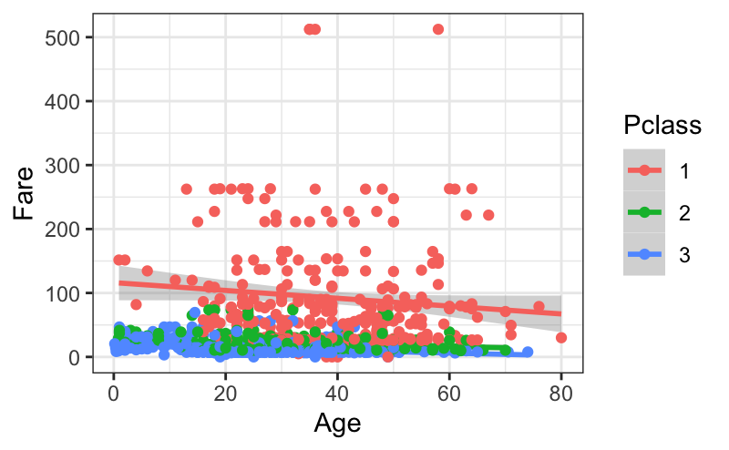

```r
# EDA for Titanic Passenger
# To see the relationship between Pclass, Age, Fare and Embarked
Passenger %>%
  ggplot(aes(x = Age, y = Fare, color = Pclass)) +
  geom_smooth(method = "lm") + geom_point() + theme_bw()
```

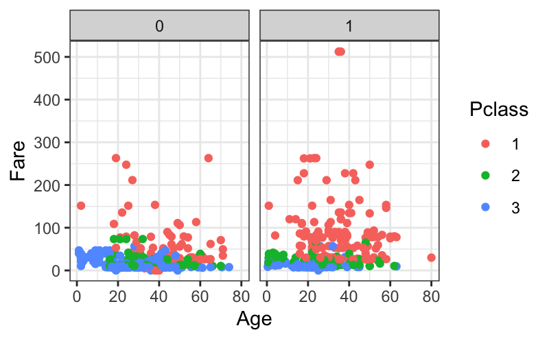

```r
# To see the relationship between Survivors, Age, Fare and Pclass
Survivor %>%
  ggplot(aes(x = Age, y = Fare, color = Pclass)) +
  geom_point() + facet_grid(.~Survived) + theme_bw()
```

To be more confident with my answer to my research question, I am adding one more graph by narrowing down the variables to see the relationship of survivors and classes as well as gender.

```
Ignoring unknown parameters: family
```

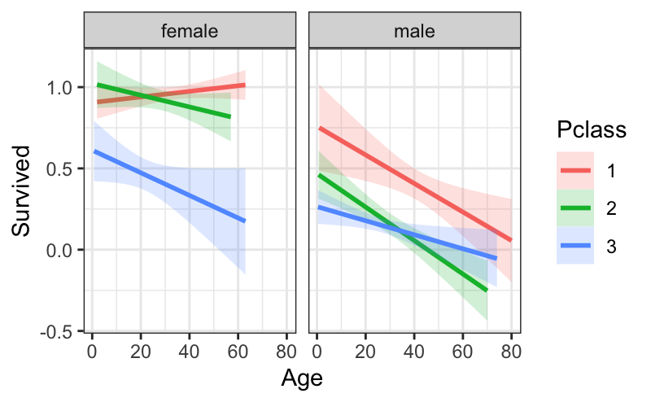

```r
# Plot to see the relationship of survivors and classes as well as gender

Survivor %>%
  ggplot(aes(Age, Survived, color = Pclass)) +
  stat_smooth(method = "glm", family = "binomial", formula = y~x, alpha = .2, aes(fill = Pclass)) +
  facet_grid(.~Sex) + theme_bw()
```